# Machine Learning / Aprendizagem Automática

**Group Number:** 28

**Members:**

- **Alexandre Baptista**, Nº 64506
- **André Pires**, Nº 64347
- **Vram Davtyan**, Nº 64691

Github Link - https://github.com/vramdavtyan/MLProjects

# AA Project - Learning about Pet Adoption using PetFinder.my Dataset

1. **Task 1 (Supervised Learning) - Predicting Adoption and Adoption Speed**
2. **Task 2 (Unsupervised Learning) - Charactering Pets and their Adoption Speed**

### File Descriptions

- **PetFinder_dataset.csv** - Tabular/text data for machine learning.
- **breed_labels.csv** - Contains Type and BreedName for each BreedID. Type 1 is dog, 2 is cat.
- **color_labels.csv** - Contains ColorName for each ColorID.
- **state_labels.csv** - Contains StateName for each StateID.

### Data Fields

- **PetID** - Unique hash ID of pet profile
- **Type** - Type of animal (1 = Dog, 2 = Cat)
- **AdoptionSpeed - Categorical speed of adoption. Lower is faster.** This is the value to predict in the competition. See section below for more info.
- **Name** - Name of pet (Empty if not named)
- **Age** - Age of pet when listed, in months
- **Breed1** - Primary breed of pet (see `BreedLabels.csv` for details)
- **Breed2** - Secondary breed of pet, if pet is of mixed breed (Refer to BreedLabels dictionary)
- **Gender** - Gender of pet (1 = Male, 2 = Female, 3 = Mixed, if profile represents group of pets)
- **Color1** - Color 1 of pet (see `ColorLabel.csv` for details)
- **Color2** - Color 2 of pet (see `ColorLabel.csv` for details)
- **Color3** - Color 3 of pet (see `ColorLabel.csv` for details)
- **MaturitySize** - Size at maturity (1 = Small, 2 = Medium, 3 = Large, 4 = Extra Large, 0 = Not Specified)
- **FurLength** - Fur length (1 = Short, 2 = Medium, 3 = Long, 0 = Not Specified)
- **Vaccinated** - Pet has been vaccinated (1 = Yes, 2 = No, 3 = Not Sure)
- **Dewormed** - Pet has been dewormed (1 = Yes, 2 = No, 3 = Not Sure)
- **Sterilized** - Pet has been spayed / neutered (1 = Yes, 2 = No, 3 = Not Sure)
- **Health** - Health Condition (1 = Healthy, 2 = Minor Injury, 3 = Serious Injury, 0 = Not Specified)
- **Quantity** - Number of pets represented in profile
- **Fee** - Adoption fee (0 = Free)
- **State** - State location in Malaysia (Refer to StateLabels dictionary)
- **RescuerID** - Unique hash ID of rescuer
- **VideoAmt** - Total uploaded videos for this pet
- **PhotoAmt** - Total uploaded photos for this pet
- **Description** - Profile write-up for this pet. The primary language used is English, with some in Malay or Chinese.

### AdoptionSpeed

The value of `AdoptionSpeed` describes how quickly, if at all, a pet is adopted:

- 0 - Pet was adopted on the same day as it was listed.
- 1 - Pet was adopted between 1 and 7 days (1st week) after being listed.
- 2 - Pet was adopted between 8 and 30 days (1st month) after being listed.
- 3 - Pet was adopted between 31 and 90 days (2nd & 3rd month) after being listed.
- 4 - No adoption after 100 days of being listed. (There are no pets in this dataset that waited between 90 and 100 days).

## Task 0 (Know your Data) - Exploratory Data Analysis

## 0.1. Loading Data

### Data Loading

This code loads the main dataset (`PetFinder_dataset.csv`) along with additional datasets for breed (`breed_labels.csv`), color (`color_labels.csv`), and state (`state_labels.csv`). These datasets provide crucial metadata about pets, including breed, color, and location. The code then prints the first three rows of each dataset to provide an initial glimpse into the data structure.

```python
from sklearn.tree import DecisionTreeClassifier
from sklearn.ensemble import RandomForestClassifier
from sklearn.linear_model import LogisticRegression
from sklearn.svm import SVC
from sklearn.model_selection import train_test_split, cross_val_score, GridSearchCV
from sklearn.naive_bayes import GaussianNB
from sklearn.metrics import classification_report, confusion_matrix, roc_auc_score, precision_recall_curve, auc, accuracy_score
from sklearn.svm import SVC
from sklearn.preprocessing import LabelEncoder, StandardScaler
from sklearn.metrics import silhouette_score, adjusted_rand_score
from sklearn.cluster import KMeans
from sklearn.decomposition import PCA

import pandas as pd
import numpy as np
import seaborn as sns
import matplotlib.pyplot as plt
plt.style.use('ggplot')

# Display inline plots for Jupyter
%matplotlib inline

import warnings
warnings.filterwarnings('ignore')


# Load the main dataset and additional CSVs
df_main = pd.read_csv('PetFinder_dataset.csv')
df_breed = pd.read_csv('breed_labels.csv')
df_color = pd.read_csv('color_labels.csv')
df_state = pd.read_csv('state_labels.csv')

# Print the first 3 rows of each dataset
print("PetFinder Dataset")
print(df_main.head(3))

print("\nBreed Labels")
print(df_breed.head(3))

print("\nColor Labels")
print(df_color.head(3))

print("\nState Labels")
print(df_state.head(3))
```

```
PetFinder Dataset
   Type         Name  Age  Breed1  Breed2  Gender  Color1  Color2  Color3  \
0     2       Nibble    3     299       0       1       1       7       0
1     2  No Name Yet    1     265       0       1       1       2       0
2     1       Brisco    1     307       0       1       2       7       0

   MaturitySize  ...  Health  Quantity  Fee  State  \
0             1  ...       1         1  100  41326
1             2  ...       1         1    0  41401
2             2  ...       1         1    0  41326

                          RescuerID  VideoAmt  \
0  8480853f516546f6cf33aa88cd76c379         0
1  3082c7125d8fb66f7dd4bff4192c8b14         0
2  fa90fa5b1ee11c86938398b60abc32cb         0

                                         Description      PetID PhotoAmt  \
0  Nibble is a 3+ month old ball of cuteness. He ...  86e1089a3      1.0
1  I just found it alone yesterday near my apartm...  6296e909a      2.0
2  Their pregnant mother was dumped by her irresp...  3422e4906      7.0

   AdoptionSpeed
0              2
1              0
2              3

[3 rows x 24 columns]

Breed Labels
   BreedID  Type         BreedName
0        1     1     Affenpinscher
1        2     1      Afghan Hound
2        3     1  Airedale Terrier

Color Labels
   ColorID ColorName
0        1     Black
1        2     Brown
2        3    Golden

State Labels
   StateID StateName
0    41336     Johor
1    41325     Kedah
2    41367  Kelantan
```

## 0.2. Understanding Data

## Data Preprocessing and Visualization

In this code block, we replace numeric values in the dataset with descriptive labels to improve interpretability. For instance, 'Gender' values are mapped to 'Male', 'Female', and 'Mixed'. This is followed by a visualization step where a set of selected features (e.g., `Type`, `Age`, `Breed1`, etc.) are plotted either as bar charts for categorical variables or histograms for numerical variables. The age data is additionally binned into categories for better visualization. The plots are organized into a grid for a comprehensive overview of the dataset's feature distributions.

1. **Label Mapping**:  
   We replaced numeric values in categorical columns with descriptive labels, making the data more interpretable (e.g., `Gender`: 1 → 'Male', `Health`: 1 → 'Healthy').
2. **Feature Distributions**:  
   We visualized the distributions of key features (`Type`, `Age`, `Breed1`, etc.). Categorical features are shown with bar charts, while numerical features like `Age` are plotted with histograms (with age binned for clarity).

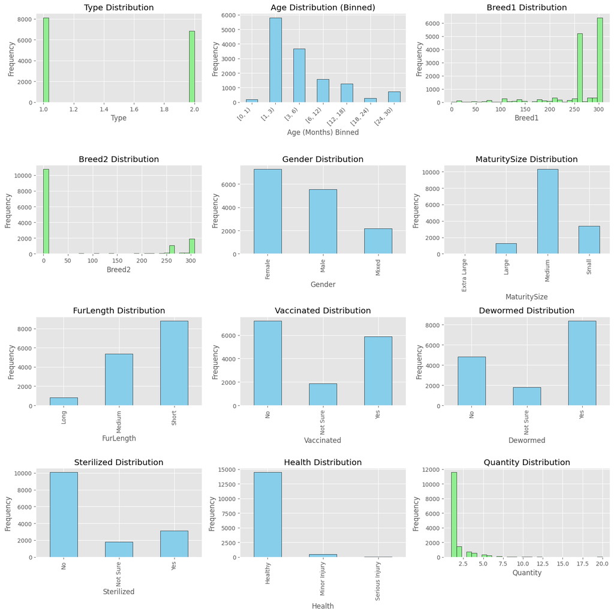

```python
df = pd.read_csv('PetFinder_dataset.csv')


# Replace numeric values with descriptive labels
label_dict = {
    'Gender': {1: 'Male', 2: 'Female', 3: 'Mixed'},
    'Vaccinated': {1: 'Yes', 2: 'No', 3: 'Not Sure'},
    'Dewormed': {1: 'Yes', 2: 'No', 3: 'Not Sure'},
    'Sterilized': {1: 'Yes', 2: 'No', 3: 'Not Sure'},
    'Health': {0: 'Not Specified', 1: 'Healthy', 2: 'Minor Injury', 3: 'Serious Injury'},
    'MaturitySize': {0: 'Not Specified', 1: 'Small', 2: 'Medium', 3: 'Large', 4: 'Extra Large'},
    'FurLength': {0: 'Not Specified', 1: 'Short', 2: 'Medium', 3: 'Long'},
    'AdoptionSpeed': {0: 'Same Day', 1: '1-7 Days', 2: '1-30 Days', 3: '31-90 Days', 4: 'Not Adopted'}
}

# Apply the labels to the dataframe
for column, mapping in label_dict.items():
    df[column] = df[column].map(mapping)

# List of columns to plot
columns_to_plot = ['Type', 'Age', 'Breed1', 'Breed2', 'Gender', 'MaturitySize',
                   'FurLength', 'Vaccinated', 'Dewormed', 'Sterilized', 'Health', 'Quantity']

plt.figure(figsize=(15, 15))

# Loop through the columns and create bar plots or histograms
for i, col in enumerate(columns_to_plot, 1):
    plt.subplot(4, 3, i)  # Create a grid of 4 rows and 3 columns for the plots
    if df[col].dtype == 'object' or df[col].dtype == 'category':  # Categorical columns
        ax = df[col].value_counts().sort_index().plot(kind='bar', color='skyblue', edgecolor='black')
        plt.title(f'{col} Distribution')
        plt.xlabel(col)
        plt.ylabel('Frequency')

        # Rotate x labels to 45 degrees where necessary (e.g., long category names)
        if len(df[col].value_counts()) > 5:  # Check if there are many unique values
            plt.xticks(rotation=45, ha='right')
    else:  # For numerical columns like 'Age' and 'Quantity', we'll use histograms
        if col == 'Age':
            # Bin 'Age' into categories for better visualization
            age_bins = [0, 1, 3, 6, 12, 18, 24, 30]
            df['Age_binned'] = pd.cut(df['Age'], bins=age_bins, right=False)
            df['Age_binned'].value_counts().sort_index().plot(kind='bar', color='skyblue', edgecolor='black')
            plt.title(f'{col} Distribution (Binned)')
            plt.xlabel('Age (Months) Binned')
            plt.ylabel('Frequency')
            plt.xticks(rotation=45, ha='right')  # Rotate x labels
        else:
            df[col].plot(kind='hist', bins=30, color='lightgreen', edgecolor='black')
            plt.title(f'{col} Distribution')
            plt.xlabel(col)
            plt.ylabel('Frequency')

    # Adjust layout to prevent overlap
    plt.tight_layout()

# Show the plot
plt.show()
```

## 1.1. Specific Data Preprocessing for Classification

## Binary Classification: Predicting Adoption

1. **Preprocessing**:  
   The dataset is preprocessed by removing irrelevant columns, converting the target variable (`AdoptionSpeed`) to a binary label (`Adopted`), and encoding categorical features using Label Encoding for ordinal columns and One-Hot Encoding for nominal columns.
2. **Model Training**:  
   Five different classifiers are trained using 5-fold cross-validation to predict whether a pet will be adopted (binary classification). The classifiers used include Decision Tree, Random Forest, Logistic Regression, Naive Bayes, and SVM.
3. **Evaluation**:  
   After training, each classifier is evaluated on the test set using accuracy, precision, recall, F1-score, and confusion matrix. The confusion matrix is visualized using a heatmap to better understand the model’s predictions.

```
Training Decision Tree...
Decision Tree Accuracy: Mean = 0.6801, Std Dev = 0.0104

Training Random Forest...
Random Forest Accuracy: Mean = 0.7507, Std Dev = 0.0068

Training Logistic Regression...
Logistic Regression Accuracy: Mean = 0.7191, Std Dev = 0.0043

Training Naive Bayes...
Naive Bayes Accuracy: Mean = 0.6851, Std Dev = 0.0097

Training SVM...
SVM Accuracy: Mean = 0.7209, Std Dev = 0.0002

Evaluating Decision Tree on the test set...
Classification Report for Decision Tree:
              precision    recall  f1-score   support

           0       0.45      0.46      0.45      1268
           1       0.79      0.78      0.78      3230

    accuracy                           0.69      4498
   macro avg       0.62      0.62      0.62      4498
weighted avg       0.69      0.69      0.69      4498

Confusion Matrix for Decision Tree:
[[ 585  683]
 [ 723 2507]]
```

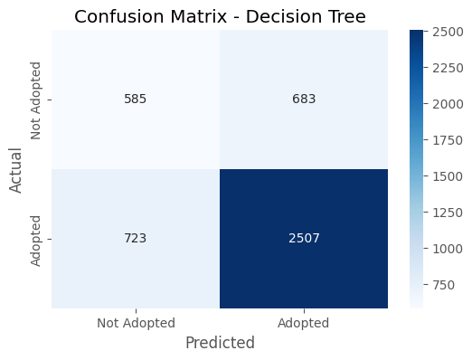

```
Evaluating Random Forest on the test set...
Classification Report for Random Forest:
              precision    recall  f1-score   support

           0       0.61      0.35      0.44      1268
           1       0.78      0.91      0.84      3230

    accuracy                           0.75      4498
   macro avg       0.70      0.63      0.64      4498
weighted avg       0.73      0.75      0.73      4498

Confusion Matrix for Random Forest:
[[ 439  829]
 [ 277 2953]]
```

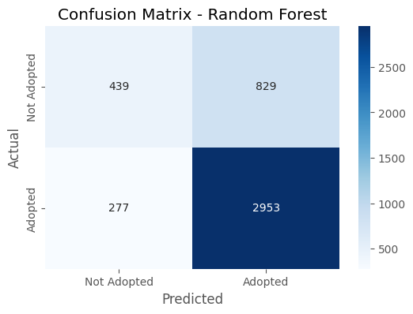

```
Evaluating Logistic Regression on the test set...
Classification Report for Logistic Regression:
              precision    recall  f1-score   support

           0       0.54      0.10      0.17      1268
           1       0.73      0.97      0.83      3230

    accuracy                           0.72      4498
   macro avg       0.64      0.53      0.50      4498
weighted avg       0.68      0.72      0.65      4498

Confusion Matrix for Logistic Regression:
[[ 124 1144]
 [ 106 3124]]
```

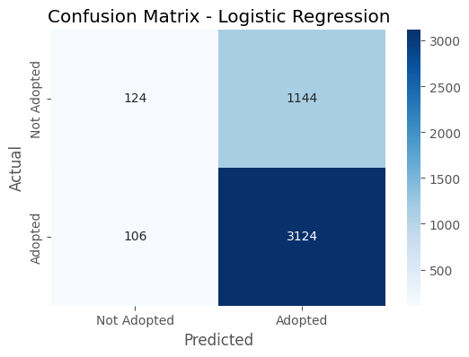

```
Evaluating Naive Bayes on the test set...
Classification Report for Naive Bayes:
              precision    recall  f1-score   support

           0       0.37      0.21      0.26      1268
           1       0.73      0.86      0.79      3230

    accuracy                           0.68      4498
   macro avg       0.55      0.53      0.53      4498
weighted avg       0.63      0.68      0.64      4498

Confusion Matrix for Naive Bayes:
[[ 260 1008]
 [ 442 2788]]
```

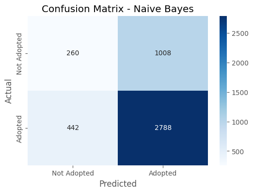

```
Evaluating SVM on the test set...
Classification Report for SVM:
              precision    recall  f1-score   support

           0       1.00      0.00      0.00      1268
           1       0.72      1.00      0.84      3230

    accuracy                           0.72      4498
   macro avg       0.86      0.50      0.42      4498
weighted avg       0.80      0.72      0.60      4498

Confusion Matrix for SVM:
[[   1 1267]
 [   0 3230]]
```

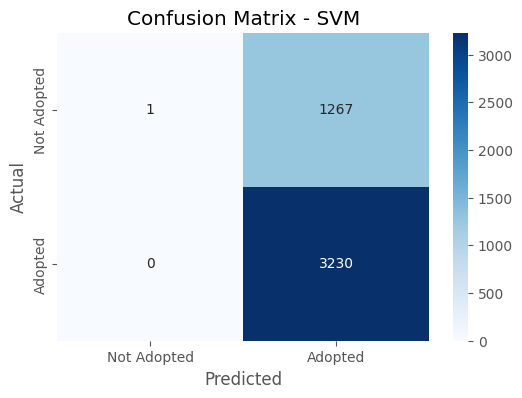

```python
df = pd.read_csv('PetFinder_dataset.csv')


# Define a function to preprocess data for binary classification
def preprocess_binary_classification(df):
    # Drop irrelevant columns
    df_cleaned = df.drop(columns=['PetID', 'RescuerID', 'Name', 'Description'])

    # Convert 'AdoptionSpeed' to binary 'Adopted' column: 1 if AdoptionSpeed != 4, 0 if AdoptionSpeed == 4
    df_cleaned['Adopted'] = df_cleaned['AdoptionSpeed'].apply(lambda x: 1 if x != 4 else 0)

    # Drop the original 'AdoptionSpeed' as it's no longer needed for binary classification
    df_cleaned = df_cleaned.drop(columns=['AdoptionSpeed'])

    # Convert categorical columns to category type
    categorical_columns = ['Type', 'Gender', 'Color1', 'Color2', 'Color3', 'MaturitySize',
                           'FurLength', 'Vaccinated', 'Dewormed', 'Sterilized', 'Health', 'State']

    for col in categorical_columns:
        df_cleaned[col] = df_cleaned[col].astype('category')

    # Apply Label Encoding to ordinal categorical columns
    label_columns = ['MaturitySize', 'FurLength', 'Vaccinated', 'Dewormed', 'Sterilized', 'Health']
    label_encoder = LabelEncoder()
    for col in label_columns:
        df_cleaned[col] = label_encoder.fit_transform(df_cleaned[col])

    # One-Hot Encoding for nominal categorical columns (e.g., 'Type', 'Gender', 'Color1', etc.)
    df_cleaned = pd.get_dummies(df_cleaned, columns=['Gender', 'Color1', 'Color2', 'Color3', 'State', 'Type'], drop_first=True)

    return df_cleaned

# Preprocess the data for binary classification
data_cleaned = preprocess_binary_classification(df)

# Prepare features (X) and target (y)
X_binary = data_cleaned.drop(columns=['Adopted'])
y_binary = data_cleaned['Adopted']

# Train-Test Split
X_train, X_test, y_train, y_test = train_test_split(X_binary, y_binary, test_size=0.3, random_state=42)

# Initialize classifiers
classifiers = {
    'Decision Tree': DecisionTreeClassifier(),
    'Random Forest': RandomForestClassifier(),
    'Logistic Regression': LogisticRegression(),
    'Naive Bayes': GaussianNB(),
    'SVM': SVC()
}

# Store cross-validation results for each classifier
cv_results = {}

# Train each classifier using cross-validation and store the results
for name, clf in classifiers.items():
    print(f"\nTraining {name}...")

    # Perform cross-validation (5-fold)
    cv_scores = cross_val_score(clf, X_train, y_train, cv=5, scoring='accuracy')
    cv_results[name] = cv_scores

    # Output the results of cross-validation
    print(f"{name} Accuracy: Mean = {np.mean(cv_scores):.4f}, Std Dev = {np.std(cv_scores):.4f}")

# Evaluate classifiers on the test set using classification report and confusion matrix
for name, clf in classifiers.items():
    print(f"\nEvaluating {name} on the test set...")

    # Fit the model on the training data
    clf.fit(X_train, y_train)

    # Predict on the test data
    y_pred = clf.predict(X_test)

    # Classification report (precision, recall, f1-score)
    print(f"Classification Report for {name}:\n{classification_report(y_test, y_pred)}")

    # Confusion matrix
    cm = confusion_matrix(y_test, y_pred)
    print(f"Confusion Matrix for {name}:\n{cm}")

    # Plot confusion matrix
    plt.figure(figsize=(6, 4))
    sns.heatmap(cm, annot=True, fmt='d', cmap='Blues', xticklabels=['Not Adopted', 'Adopted'], yticklabels=['Not Adopted', 'Adopted'])
    plt.title(f'Confusion Matrix - {name}')
    plt.xlabel('Predicted')
    plt.ylabel('Actual')
    plt.show()
```

## Enhanced Binary Classification with Hyperparameter Tuning

1. **Data Preprocessing**:  
   The dataset is preprocessed by filling missing values, dropping irrelevant columns, and transforming the target variable `AdoptionSpeed` into a binary target `Adopted` (1 for adopted pets, 0 for non-adopted). Categorical columns are encoded using Label Encoding for ordinal features and One-Hot Encoding for nominal features.
2. **Model Training & Evaluation**:  
   Five classifiers are trained (Decision Tree, Random Forest, Logistic Regression, Naive Bayes, and SVM) and evaluated on a binary classification task. Cross-validation scores and confusion matrices are displayed for each classifier, and classification performance is assessed using precision, recall, F1-score, and ROC AUC.
3. **ROC AUC & Precision-Recall Curve**:  
   For classifiers capable of providing probability estimates (SVM, Random Forest, and Logistic Regression), ROC AUC and Precision-Recall AUC scores are computed to evaluate model performance on imbalanced classes.
4. **Hyperparameter Tuning (Random Forest)**:  
   GridSearchCV is used for hyperparameter tuning on the Random Forest classifier to find the optimal parameters, followed by re-evaluation on the test set with the best model.

```
Training Decision Tree...
Decision Tree Accuracy: Mean = 0.6806, Std Dev = 0.0100

Training Random Forest...
Random Forest Accuracy: Mean = 0.7505, Std Dev = 0.0073

Training Logistic Regression...
Logistic Regression Accuracy: Mean = 0.7267, Std Dev = 0.0034

Training Naive Bayes...
Naive Bayes Accuracy: Mean = 0.6851, Std Dev = 0.0097

Training SVM...
SVM Accuracy: Mean = 0.7209, Std Dev = 0.0002

Evaluating Decision Tree on the test set...
Classification Report for Decision Tree:
              precision    recall  f1-score   support

           0       0.44      0.46      0.45      1268
           1       0.78      0.77      0.78      3230

    accuracy                           0.68      4498
   macro avg       0.61      0.61      0.61      4498
weighted avg       0.69      0.68      0.68      4498

Confusion Matrix for Decision Tree:
[[ 583  685]
 [ 748 2482]]
```

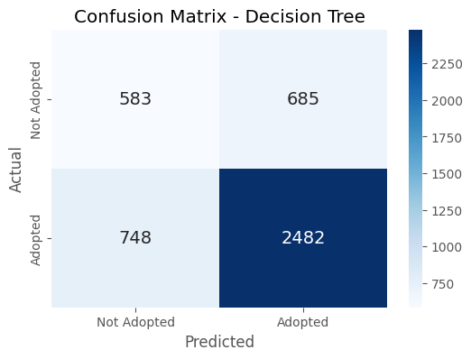

```
Evaluating Random Forest on the test set...
Classification Report for Random Forest:
              precision    recall  f1-score   support

           0       0.62      0.34      0.44      1268
           1       0.78      0.92      0.84      3230

    accuracy                           0.76      4498
   macro avg       0.70      0.63      0.64      4498
weighted avg       0.73      0.76      0.73      4498

Confusion Matrix for Random Forest:
[[ 431  837]
 [ 265 2965]]
```

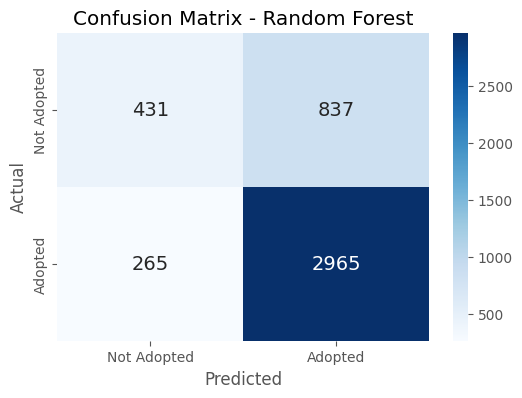

```
ROC AUC for Random Forest: 0.7688
Precision-Recall AUC for Random Forest: 0.8868
Best parameters for Random Forest: {'max_depth': None, 'min_samples_leaf': 2, 'min_samples_split': 10, 'n_estimators': 200}
Best cross-validation score for Random Forest: 0.7575
Classification Report for Random Forest (tuned):
              precision    recall  f1-score   support

           0       0.66      0.26      0.38      1268
           1       0.77      0.95      0.85      3230

    accuracy                           0.75      4498
   macro avg       0.71      0.61      0.61      4498
weighted avg       0.74      0.75      0.71      4498

Confusion Matrix for Random Forest (tuned):
[[ 335  933]
 [ 175 3055]]
```

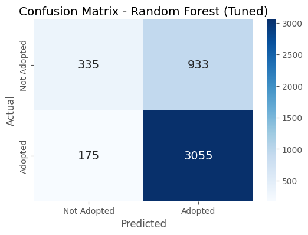

```
Evaluating Logistic Regression on the test set...
Classification Report for Logistic Regression:
              precision    recall  f1-score   support

           0       0.58      0.10      0.17      1268
           1       0.73      0.97      0.84      3230

    accuracy                           0.73      4498
   macro avg       0.66      0.54      0.51      4498
weighted avg       0.69      0.73      0.65      4498

Confusion Matrix for Logistic Regression:
[[ 130 1138]
 [  94 3136]]
```

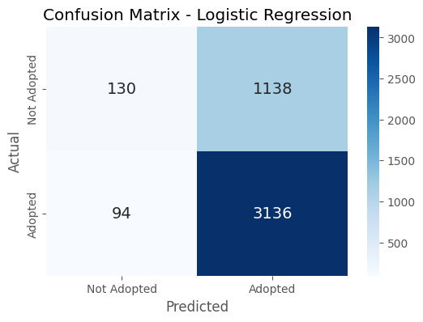

```
ROC AUC for Logistic Regression: 0.6844
Precision-Recall AUC for Logistic Regression: 0.8354

Evaluating Naive Bayes on the test set...
Classification Report for Naive Bayes:
              precision    recall  f1-score   support

           0       0.37      0.21      0.26      1268
           1       0.73      0.86      0.79      3230

    accuracy                           0.68      4498
   macro avg       0.55      0.53      0.53      4498
weighted avg       0.63      0.68      0.64      4498

Confusion Matrix for Naive Bayes:
[[ 260 1008]
 [ 442 2788]]
```

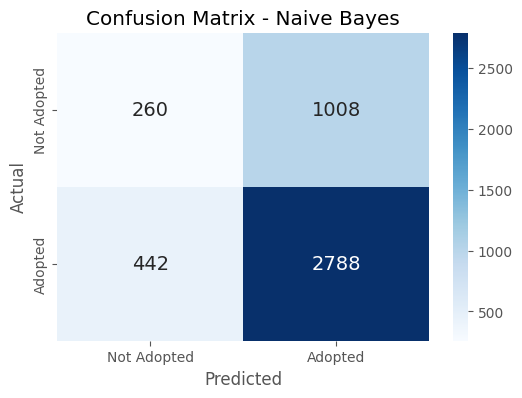

```
Evaluating SVM on the test set...
Classification Report for SVM:
              precision    recall  f1-score   support

           0       1.00      0.00      0.00      1268
           1       0.72      1.00      0.84      3230

    accuracy                           0.72      4498
   macro avg       0.86      0.50      0.42      4498
weighted avg       0.80      0.72      0.60      4498

Confusion Matrix for SVM:
[[   1 1267]
 [   0 3230]]
```

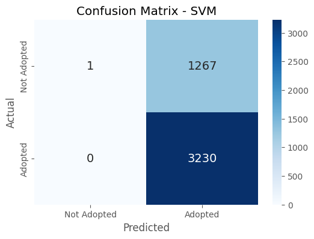

```
ROC AUC for SVM: 0.7167
Precision-Recall AUC for SVM: 0.8432
```

```python
df = pd.read_csv('PetFinder_dataset.csv')


# Define a function to preprocess data for binary classification
def preprocess_binary_classification(df):
    # Handle missing values (fill with mode for categorical, mean for numerical)
    df = df.fillna(df.mode().iloc[0])  # Fill categorical columns with mode

    # Drop irrelevant columns
    df_cleaned = df.drop(columns=['PetID', 'RescuerID', 'Name', 'Description'])

    # Convert 'AdoptionSpeed' to binary 'Adopted' column: 1 if AdoptionSpeed != 4, 0 if AdoptionSpeed == 4
    df_cleaned['Adopted'] = df_cleaned['AdoptionSpeed'].apply(lambda x: 1 if x != 4 else 0)

    # Drop the original 'AdoptionSpeed' as it's no longer needed for binary classification
    df_cleaned = df_cleaned.drop(columns=['AdoptionSpeed'])

    # Convert categorical columns to category type
    categorical_columns = ['Type', 'Gender', 'Color1', 'Color2', 'Color3', 'MaturitySize',
                           'FurLength', 'Vaccinated', 'Dewormed', 'Sterilized', 'Health', 'State']

    for col in categorical_columns:
        df_cleaned[col] = df_cleaned[col].astype('category')

    # Apply Label Encoding to ordinal categorical columns
    label_columns = ['MaturitySize', 'FurLength', 'Vaccinated', 'Dewormed', 'Sterilized', 'Health']
    label_encoder = LabelEncoder()
    for col in label_columns:
        df_cleaned[col] = label_encoder.fit_transform(df_cleaned[col])

    # One-Hot Encoding for nominal categorical columns (e.g., 'Type', 'Gender', 'Color1', etc.)
    df_cleaned = pd.get_dummies(df_cleaned, columns=['Gender', 'Color1', 'Color2', 'Color3', 'State', 'Type'], drop_first=True)

    return df_cleaned

# Preprocess the data for binary classification
data_cleaned = preprocess_binary_classification(df)

# Prepare features (X) and target (y)
X_binary = data_cleaned.drop(columns=['Adopted'])
y_binary = data_cleaned['Adopted']

# Train-Test Split
X_train, X_test, y_train, y_test = train_test_split(X_binary, y_binary, test_size=0.3, random_state=42)

# Initialize classifiers
classifiers = {
    'Decision Tree': DecisionTreeClassifier(),
    'Random Forest': RandomForestClassifier(),
    'Logistic Regression': LogisticRegression(max_iter=1000),
    'Naive Bayes': GaussianNB(),
    'SVM': SVC(probability=True)  # Ensure SVM outputs probabilities for ROC AUC
}

# Store cross-validation results for each classifier
cv_results = {}

# Train each classifier using cross-validation and store the results
for name, clf in classifiers.items():
    print(f"\nTraining {name}...")

    # Perform cross-validation (5-fold)
    cv_scores = cross_val_score(clf, X_train, y_train, cv=5, scoring='accuracy')
    cv_results[name] = cv_scores

    # Output the results of cross-validation
    print(f"{name} Accuracy: Mean = {np.mean(cv_scores):.4f}, Std Dev = {np.std(cv_scores):.4f}")

# Evaluate classifiers on the test set using classification report and confusion matrix
for name, clf in classifiers.items():
    print(f"\nEvaluating {name} on the test set...")

    # Fit the model on the training data
    clf.fit(X_train, y_train)

    # Predict on the test data
    y_pred = clf.predict(X_test)

    # Classification report (precision, recall, f1-score)
    print(f"Classification Report for {name}:\n{classification_report(y_test, y_pred)}")

    # Confusion matrix
    cm = confusion_matrix(y_test, y_pred)
    print(f"Confusion Matrix for {name}:\n{cm}")

    # Plot confusion matrix
    plt.figure(figsize=(6, 4))
    sns.heatmap(cm, annot=True, fmt='d', cmap='Blues', annot_kws={"size": 14},
                xticklabels=['Not Adopted', 'Adopted'], yticklabels=['Not Adopted', 'Adopted'])
    plt.title(f'Confusion Matrix - {name}')
    plt.xlabel('Predicted')
    plt.ylabel('Actual')
    plt.show()

    # ROC AUC Score (for SVM, Random Forest, Logistic Regression)
    if name in ['SVM', 'Random Forest', 'Logistic Regression']:
        y_pred_prob = clf.predict_proba(X_test)[:, 1]  # Probability estimates for the positive class
        auc_score = roc_auc_score(y_test, y_pred_prob)
        print(f"ROC AUC for {name}: {auc_score:.4f}")

        # Precision-Recall Curve and AUC
        precision, recall, _ = precision_recall_curve(y_test, y_pred_prob)
        pr_auc = auc(recall, precision)
        print(f"Precision-Recall AUC for {name}: {pr_auc:.4f}")

    # Hyperparameter tuning using GridSearchCV (for Random Forest as an example)
    if name == 'Random Forest':
        param_grid = {
            'n_estimators': [100, 200, 300],
            'max_depth': [None, 10, 20, 30],
            'min_samples_split': [2, 5, 10],
            'min_samples_leaf': [1, 2, 4]
        }
        grid_search = GridSearchCV(clf, param_grid, cv=5, n_jobs=-1, scoring='accuracy')
        grid_search.fit(X_train, y_train)
        print(f"Best parameters for {name}: {grid_search.best_params_}")
        print(f"Best cross-validation score for {name}: {grid_search.best_score_:.4f}")

        # Re-evaluate with the best parameters found by GridSearchCV
        best_rf = grid_search.best_estimator_
        y_pred_rf = best_rf.predict(X_test)
        print(f"Classification Report for Random Forest (tuned):\n{classification_report(y_test, y_pred_rf)}")

        # Confusion Matrix for the tuned model
        cm_rf = confusion_matrix(y_test, y_pred_rf)
        print(f"Confusion Matrix for Random Forest (tuned):\n{cm_rf}")

        # Plot confusion matrix
        plt.figure(figsize=(6, 4))
        sns.heatmap(cm_rf, annot=True, fmt='d', cmap='Blues', annot_kws={"size": 14},
                    xticklabels=['Not Adopted', 'Adopted'], yticklabels=['Not Adopted', 'Adopted'])
        plt.title(f'Confusion Matrix - Random Forest (Tuned)')
        plt.xlabel('Predicted')
        plt.ylabel('Actual')
        plt.show()
```

## 1.2. Learning and Evaluating Classifiers

## Multiclass Classification with Hyperparameter Tuning

1. **Data Preprocessing**:  
   The dataset is preprocessed by filling missing values, dropping irrelevant columns, and encoding both ordinal and nominal categorical features. The target variable `AdoptionSpeed` remains unchanged (with 5 classes: 0 to 4).
2. **Model Training & Evaluation**:  
   Five classifiers (Decision Tree, Random Forest, Logistic Regression, Naive Bayes, and SVM) are trained on the dataset, evaluated using cross-validation, and assessed on the test set. The performance is measured with a classification report (precision, recall, F1-score) and confusion matrix.
3. **Confusion Matrix Visualization**:  
   The confusion matrix for each model is plotted to visualize the classification performance across the 5 possible target classes (0-4).
4. **Hyperparameter Tuning (Random Forest)**:  
   For Random Forest, hyperparameter tuning is performed using `GridSearchCV` to find the optimal model parameters. The best model is then re-evaluated on the test set, and its confusion matrix is plotted to compare performance before and after tuning.

```
Training Decision Tree...
Decision Tree Accuracy: Mean = 0.3299, Std Dev = 0.0086

Training Random Forest...
Random Forest Accuracy: Mean = 0.3895, Std Dev = 0.0062

Training Logistic Regression...
Logistic Regression Accuracy: Mean = 0.3497, Std Dev = 0.0065

Training Naive Bayes...
Naive Bayes Accuracy: Mean = 0.1984, Std Dev = 0.0270

Training SVM...
SVM Accuracy: Mean = 0.3285, Std Dev = 0.0143

Evaluating Decision Tree on the test set...
Classification Report for Decision Tree:
              precision    recall  f1-score   support

           0       0.09      0.08      0.08       141
           1       0.29      0.30      0.29       928
           2       0.31      0.32      0.31      1177
           3       0.29      0.29      0.29       984
           4       0.45      0.43      0.44      1268

    accuracy                           0.33      4498
   macro avg       0.28      0.28      0.28      4498
weighted avg       0.33      0.33      0.33      4498

Confusion Matrix for Decision Tree:
[[ 11  38  35  22  35]
 [ 32 278 284 174 160]
 [ 32 270 373 258 244]
 [ 25 195 251 284 229]
 [ 23 185 273 242 545]]
```

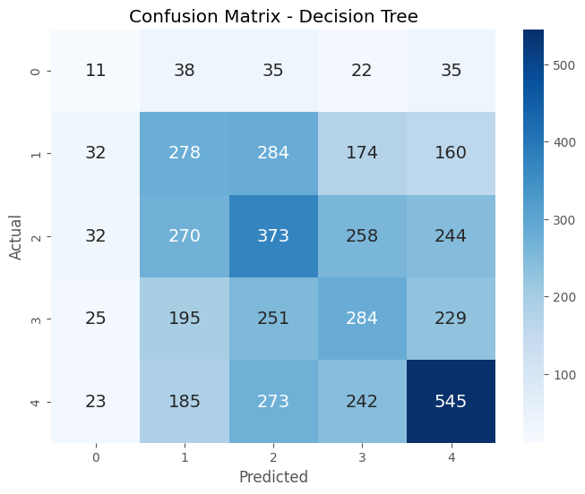

```
Evaluating Random Forest on the test set...
Classification Report for Random Forest:
              precision    recall  f1-score   support

           0       0.39      0.05      0.09       141
           1       0.37      0.34      0.35       928
           2       0.33      0.36      0.35      1177
           3       0.35      0.27      0.30       984
           4       0.50      0.63      0.56      1268

    accuracy                           0.40      4498
   macro avg       0.39      0.33      0.33      4498
weighted avg       0.39      0.40      0.39      4498

Confusion Matrix for Random Forest:
[[  7  41  39  12  42]
 [  3 316 318 124 167]
 [  2 238 429 211 297]
 [  3 163 280 262 276]
 [  3 106 233 133 793]]
```

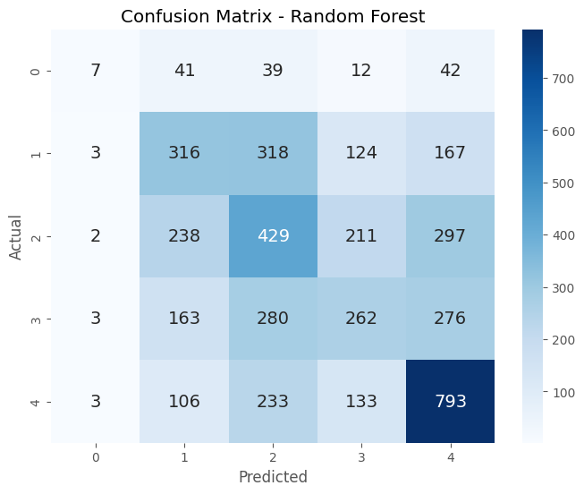

```
Evaluating Logistic Regression on the test set...
Classification Report for Logistic Regression:
              precision    recall  f1-score   support

           0       0.00      0.00      0.00       141
           1       0.31      0.24      0.27       928
           2       0.31      0.36      0.33      1177
           3       0.35      0.15      0.21       984
           4       0.40      0.62      0.49      1268

    accuracy                           0.35      4498
   macro avg       0.27      0.27      0.26      4498
weighted avg       0.33      0.35      0.32      4498

Confusion Matrix for Logistic Regression:
[[  0  47  33   8  53]
 [  0 222 362  60 284]
 [  0 187 421 112 457]
 [  0 128 310 146 400]
 [  0 138 251  89 790]]
```

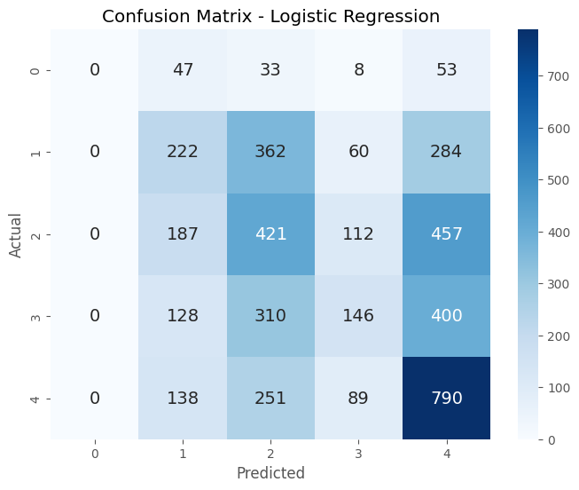

```
Evaluating Naive Bayes on the test set...
Classification Report for Naive Bayes:
              precision    recall  f1-score   support

           0       0.05      0.43      0.09       141
           1       0.25      0.41      0.31       928
           2       0.29      0.33      0.31      1177
           3       0.33      0.06      0.10       984
           4       0.42      0.09      0.14      1268

    accuracy                           0.22      4498
   macro avg       0.27      0.26      0.19      4498
weighted avg       0.32      0.22      0.21      4498

Confusion Matrix for Naive Bayes:
[[ 60  49  25   2   5]
 [263 377 230  23  35]
 [292 400 392  42  51]
 [248 303 317  58  58]
 [330 369 411  50 108]]
```

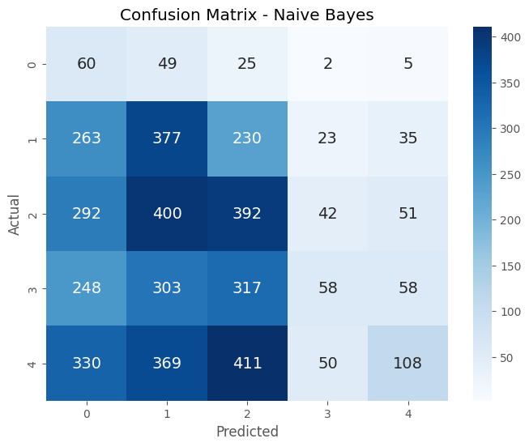

```
Evaluating SVM on the test set...
Classification Report for SVM:
              precision    recall  f1-score   support

           0       0.00      0.00      0.00       141
           1       0.36      0.05      0.08       928
           2       0.27      0.60      0.38      1177
           3       0.39      0.06      0.10       984
           4       0.39      0.51      0.44      1268

    accuracy                           0.32      4498
   macro avg       0.28      0.24      0.20      4498
weighted avg       0.34      0.32      0.26      4498

Confusion Matrix for SVM:
[[  0   9 108   3  21]
 [  0  44 653  21 210]
 [  0  29 708  40 400]
 [  0  26 538  57 363]
 [  0  14 587  26 641]]
```

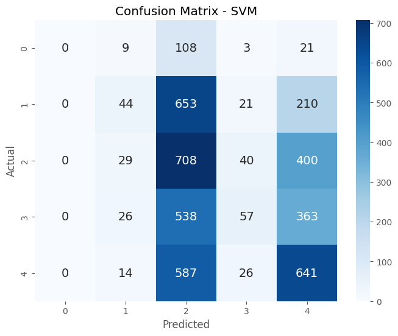

```
Best parameters for Random Forest: {'max_depth': 30, 'min_samples_leaf': 2, 'min_samples_split': 5, 'n_estimators': 300}
Best cross-validation score for Random Forest: 0.4091
Classification Report for Random Forest (tuned):
              precision    recall  f1-score   support

           0       1.00      0.02      0.04       141
           1       0.38      0.32      0.35       928
           2       0.35      0.43      0.39      1177
           3       0.42      0.22      0.29       984
           4       0.50      0.69      0.58      1268

    accuracy                           0.42      4498
   macro avg       0.53      0.34      0.33      4498
weighted avg       0.43      0.42      0.40      4498

Confusion Matrix for Random Forest (tuned):
[[  3  46  43  10  39]
 [  0 300 375  76 177]
 [  0 203 508 145 321]
 [  0 140 303 221 320]
 [  0  92 227  80 869]]
```

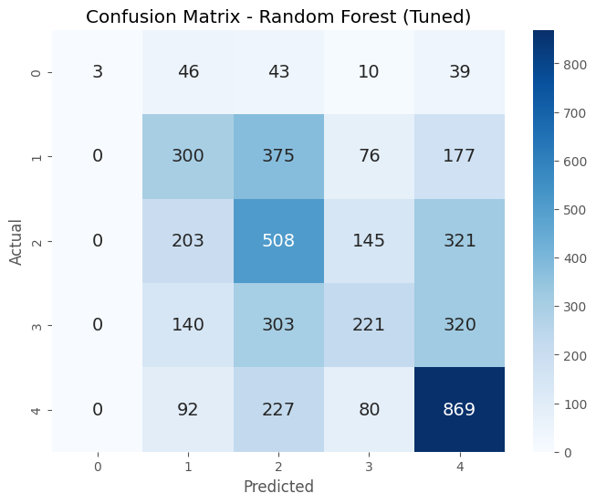

```python
df = pd.read_csv('PetFinder_dataset.csv')


# Define a function to preprocess data for multiclass classification
def preprocess_multiclass_classification(df):
    # Handle missing values (fill with mode for categorical, mean for numerical)
    df = df.fillna(df.mode().iloc[0])  # Fill categorical columns with mode

    # Drop irrelevant columns
    df_cleaned = df.drop(columns=['PetID', 'RescuerID', 'Name', 'Description'])

    # The target variable is AdoptionSpeed (original 5 classes: 0, 1, 2, 3, 4)
    # No transformation needed for the target here; we will keep it as it is.

    # Convert categorical columns to category type
    categorical_columns = ['Type', 'Gender', 'Color1', 'Color2', 'Color3', 'MaturitySize',
                           'FurLength', 'Vaccinated', 'Dewormed', 'Sterilized', 'Health', 'State']

    for col in categorical_columns:
        df_cleaned[col] = df_cleaned[col].astype('category')

    # Apply Label Encoding to ordinal categorical columns
    label_columns = ['MaturitySize', 'FurLength', 'Vaccinated', 'Dewormed', 'Sterilized', 'Health']
    label_encoder = LabelEncoder()
    for col in label_columns:
        df_cleaned[col] = label_encoder.fit_transform(df_cleaned[col])

    # One-Hot Encoding for nominal categorical columns (e.g., 'Type', 'Gender', 'Color1', etc.)
    df_cleaned = pd.get_dummies(df_cleaned, columns=['Gender', 'Color1', 'Color2', 'Color3', 'State', 'Type'], drop_first=True)

    return df_cleaned

# Preprocess the data for multiclass classification
data_cleaned = preprocess_multiclass_classification(df)

# Prepare features (X) and target (y)
X_multiclass = data_cleaned.drop(columns=['AdoptionSpeed'])
y_multiclass = data_cleaned['AdoptionSpeed']

# Train-Test Split
X_train, X_test, y_train, y_test = train_test_split(X_multiclass, y_multiclass, test_size=0.3, random_state=42)

# Initialize classifiers
classifiers = {
    'Decision Tree': DecisionTreeClassifier(),
    'Random Forest': RandomForestClassifier(),
    'Logistic Regression': LogisticRegression(max_iter=1000),
    'Naive Bayes': GaussianNB(),
    'SVM': SVC(probability=True)  # Ensure SVM outputs probabilities for metrics like ROC AUC
}

# Store cross-validation results for each classifier
cv_results = {}

# Train each classifier using cross-validation and store the results
for name, clf in classifiers.items():
    print(f"\nTraining {name}...")

    # Perform cross-validation (5-fold)
    cv_scores = cross_val_score(clf, X_train, y_train, cv=5, scoring='accuracy')
    cv_results[name] = cv_scores

    # Output the results of cross-validation
    print(f"{name} Accuracy: Mean = {np.mean(cv_scores):.4f}, Std Dev = {np.std(cv_scores):.4f}")

# Evaluate classifiers on the test set using classification report and confusion matrix
for name, clf in classifiers.items():
    print(f"\nEvaluating {name} on the test set...")

    # Fit the model on the training data
    clf.fit(X_train, y_train)

    # Predict on the test data
    y_pred = clf.predict(X_test)

    # Classification report (precision, recall, f1-score) for multiclass
    print(f"Classification Report for {name}:\n{classification_report(y_test, y_pred)}")

    # Confusion matrix
    cm = confusion_matrix(y_test, y_pred)
    print(f"Confusion Matrix for {name}:\n{cm}")

    # Plot confusion matrix
    plt.figure(figsize=(8, 6))
    sns.heatmap(cm, annot=True, fmt='d', cmap='Blues', annot_kws={"size": 14},
                xticklabels=['0', '1', '2', '3', '4'], yticklabels=['0', '1', '2', '3', '4'])
    plt.title(f'Confusion Matrix - {name}')
    plt.xlabel('Predicted')
    plt.ylabel('Actual')
    plt.show()

# Hyperparameter tuning using GridSearchCV (for Random Forest as an example)
for name, clf in classifiers.items():
    if name == 'Random Forest':
        param_grid = {
            'n_estimators': [100, 200, 300],
            'max_depth': [None, 10, 20, 30],
            'min_samples_split': [2, 5, 10],
            'min_samples_leaf': [1, 2, 4]
        }
        grid_search = GridSearchCV(clf, param_grid, cv=5, n_jobs=-1, scoring='accuracy')
        grid_search.fit(X_train, y_train)
        print(f"\nBest parameters for {name}: {grid_search.best_params_}")
        print(f"Best cross-validation score for {name}: {grid_search.best_score_:.4f}")

        # Re-evaluate with the best parameters found by GridSearchCV
        best_rf = grid_search.best_estimator_
        y_pred_rf = best_rf.predict(X_test)
        print(f"Classification Report for Random Forest (tuned):\n{classification_report(y_test, y_pred_rf)}")

        # Confusion Matrix for the tuned model
        cm_rf = confusion_matrix(y_test, y_pred_rf)
        print(f"Confusion Matrix for Random Forest (tuned):\n{cm_rf}")

        # Plot confusion matrix for tuned model
        plt.figure(figsize=(8, 6))
        sns.heatmap(cm_rf, annot=True, fmt='d', cmap='Blues', annot_kws={"size": 14},
                    xticklabels=['0', '1', '2', '3', '4'], yticklabels=['0', '1', '2', '3', '4'])
        plt.title(f'Confusion Matrix - Random Forest (Tuned)')
        plt.xlabel('Predicted')
        plt.ylabel('Actual')
        plt.show()
```

## 1.3. Classification - Final Discussion and Conclusions

This section classifies pet adoption data from the **PetFinder dataset** into two categories:

1. **Binary Classification (Adopted vs Not Adopted)**:
   - The target variable is derived from the 'AdoptionSpeed' column, where pets with an adoption speed of 4 (not adopted) are labeled as 0, and all others as 1 (adopted).
   - The script handles data preprocessing by encoding categorical features (like type, color, health, etc.) using label encoding and one-hot encoding.
   - Various classifiers (Decision Tree, Random Forest, Logistic Regression, Naive Bayes, and SVM) are trained and evaluated for binary classification.
2. **Multiclass Classification (Adoption Speed: 0-4)**:
   - This classification predicts the adoption speed (0: very fast, 4: very slow) of pets based on features such as pet type, age, and health status.
   - Data preprocessing includes encoding ordinal categorical variables and one-hot encoding for nominal variables.
   - The classifiers are also trained and evaluated for multiclass classification.

The code performs the following steps:

- **Data Preprocessing**: Cleans the dataset by handling missing values, encoding categorical features, and splitting the data into train and test sets.
- **Model Training**: Uses a variety of classifiers to fit the models for both binary and multiclass problems.
- **Model Evaluation**: Evaluates model performance using classification reports and confusion matrices, visualized through heatmaps.

The dataset is split into separate sets for **cats** and **dogs**, allowing for both binary and multiclass classification tasks to be performed on each group separately.

```
Evaluating Cats - Binary Classification (Adopted)

Decision Tree - Cats Binary:
Classification Report:
              precision    recall  f1-score   support

           0       0.37      0.38      0.38       525
           1       0.79      0.78      0.78      1534

    accuracy                           0.68      2059
   macro avg       0.58      0.58      0.58      2059
weighted avg       0.68      0.68      0.68      2059

Confusion Matrix:
[[ 202  323]
 [ 337 1197]]
```

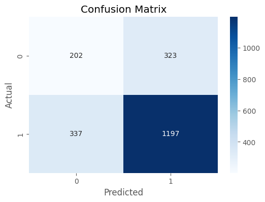

```
Random Forest - Cats Binary:
Classification Report:
              precision    recall  f1-score   support

           0       0.54      0.25      0.34       525
           1       0.78      0.93      0.85      1534

    accuracy                           0.75      2059
   macro avg       0.66      0.59      0.60      2059
weighted avg       0.72      0.75      0.72      2059

Confusion Matrix:
[[ 131  394]
 [ 111 1423]]
```

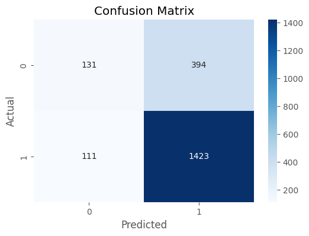

```
Logistic Regression - Cats Binary:
Classification Report:
              precision    recall  f1-score   support

           0       0.54      0.07      0.13       525
           1       0.76      0.98      0.85      1534

    accuracy                           0.75      2059
   macro avg       0.65      0.53      0.49      2059
weighted avg       0.70      0.75      0.67      2059

Confusion Matrix:
[[  39  486]
 [  33 1501]]
```

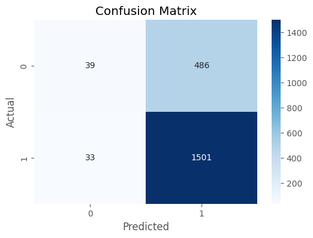

```
Naive Bayes - Cats Binary:
Classification Report:
              precision    recall  f1-score   support

           0       0.34      0.09      0.14       525
           1       0.75      0.94      0.84      1534

    accuracy                           0.72      2059
   macro avg       0.54      0.51      0.49      2059
weighted avg       0.64      0.72      0.66      2059

Confusion Matrix:
[[  45  480]
 [  89 1445]]
```

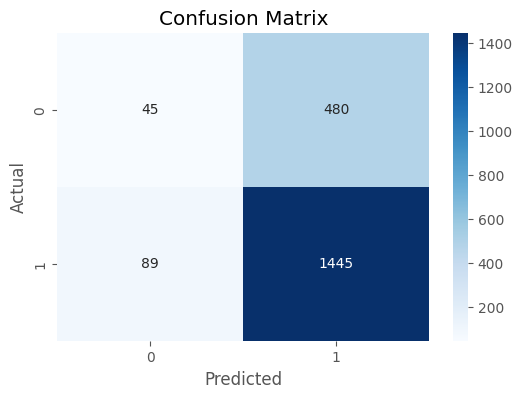

```
SVM - Cats Binary:
Classification Report:
              precision    recall  f1-score   support

           0       0.00      0.00      0.00       525
           1       0.75      1.00      0.85      1534

    accuracy                           0.75      2059
   macro avg       0.37      0.50      0.43      2059
weighted avg       0.56      0.75      0.64      2059

Confusion Matrix:
[[   0  525]
 [   0 1534]]
```

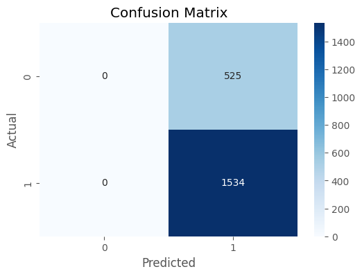

```
Evaluating Cats - Multiclass Classification (AdoptionSpeed)

Decision Tree - Cats Multiclass:
Classification Report:
              precision    recall  f1-score   support

           0       0.11      0.12      0.11        77
           1       0.33      0.32      0.33       520
           2       0.29      0.29      0.29       545
           3       0.21      0.21      0.21       392
           4       0.36      0.36      0.36       525

    accuracy                           0.29      2059
   macro avg       0.26      0.26      0.26      2059
weighted avg       0.30      0.29      0.30      2059

Confusion Matrix:
[[  9  19  20  10  19]
 [ 20 167 142  96  95]
 [ 19 141 159 113 113]
 [ 11  85 104  84 108]
 [ 25  90 127  95 188]]
```

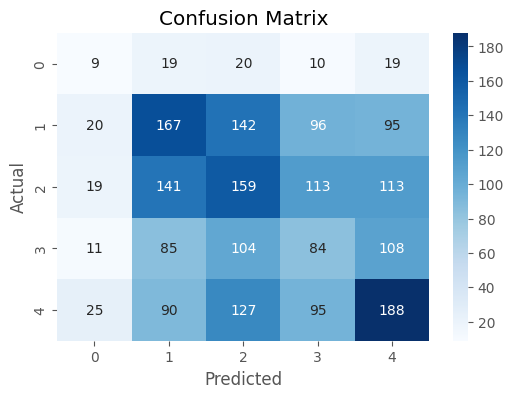

```
Random Forest - Cats Multiclass:
Classification Report:
              precision    recall  f1-score   support

           0       0.25      0.05      0.09        77
           1       0.35      0.37      0.36       520
           2       0.30      0.37      0.33       545
           3       0.29      0.14      0.19       392
           4       0.44      0.54      0.48       525

    accuracy                           0.36      2059
   macro avg       0.33      0.29      0.29      2059
weighted avg       0.35      0.36      0.34      2059

Confusion Matrix:
[[  4  29  22   5  17]
 [  4 192 179  47  98]
 [  3 156 199  50 137]
 [  2  93 127  56 114]
 [  3  73 128  36 285]]
```

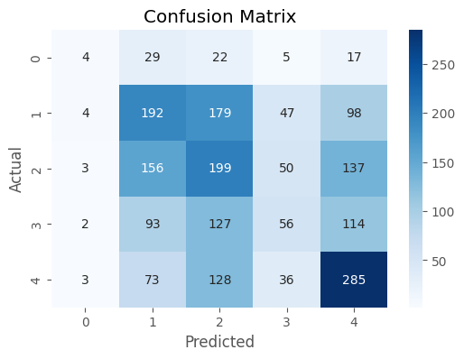

```
Logistic Regression - Cats Multiclass:
Classification Report:
              precision    recall  f1-score   support

           0       0.00      0.00      0.00        77
           1       0.32      0.29      0.30       520
           2       0.29      0.42      0.34       545
           3       0.34      0.10      0.15       392
           4       0.39      0.51      0.44       525

    accuracy                           0.33      2059
   macro avg       0.27      0.26      0.25      2059
weighted avg       0.32      0.33      0.31      2059

Confusion Matrix:
[[  0  32  21   7  17]
 [  0 150 226  24 120]
 [  0 127 228  27 163]
 [  0  70 157  39 126]
 [  0  89 148  19 269]]
```

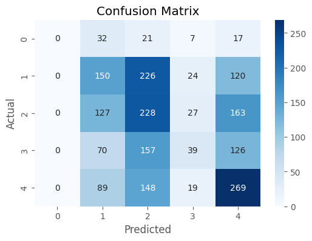

```
Naive Bayes - Cats Multiclass:
Classification Report:
              precision    recall  f1-score   support

           0       0.06      0.55      0.10        77
           1       0.32      0.19      0.24       520
           2       0.29      0.44      0.35       545
           3       0.32      0.10      0.15       392
           4       0.42      0.03      0.05       525

    accuracy                           0.21      2059
   macro avg       0.28      0.26      0.18      2059
weighted avg       0.33      0.21      0.20      2059

Confusion Matrix:
[[ 42   7  22   3   3]
 [201  99 196  21   3]
 [194  83 241  22   5]
 [118  57 169  38  10]
 [200  65 209  36  15]]
```

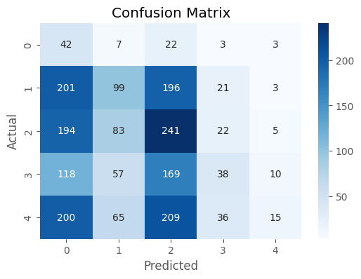

```
SVM - Cats Multiclass:
Classification Report:
              precision    recall  f1-score   support

           0       0.00      0.00      0.00        77
           1       0.00      0.00      0.00       520
           2       0.27      0.91      0.41       545
           3       0.00      0.00      0.00       392
           4       0.42      0.17      0.25       525

    accuracy                           0.28      2059
   macro avg       0.14      0.22      0.13      2059
weighted avg       0.18      0.28      0.17      2059

Confusion Matrix:
[[  0   0  73   0   4]
 [  0   0 492   0  28]
 [  0   0 494   0  51]
 [  0   0 350   0  42]
 [  0   0 434   0  91]]
```

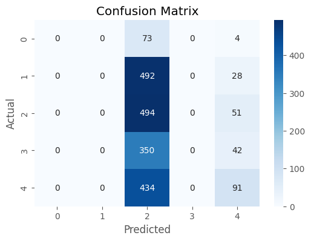

```
Evaluating Dogs - Binary Classification (Adopted)

Decision Tree - Dogs Binary:
Classification Report:
              precision    recall  f1-score   support

           0       0.49      0.54      0.51       717
           1       0.80      0.77      0.78      1723

    accuracy                           0.70      2440
   macro avg       0.65      0.65      0.65      2440
weighted avg       0.71      0.70      0.70      2440

Confusion Matrix:
[[ 387  330]
 [ 400 1323]]
```

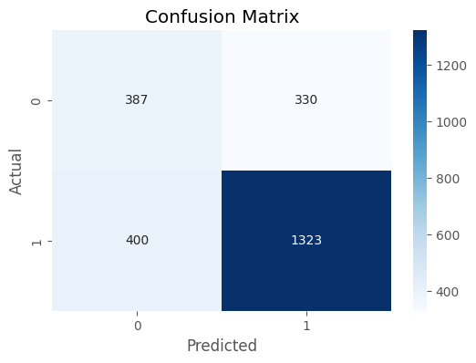

```
Random Forest - Dogs Binary:
Classification Report:
              precision    recall  f1-score   support

           0       0.62      0.44      0.52       717
           1       0.79      0.89      0.84      1723

    accuracy                           0.76      2440
   macro avg       0.70      0.66      0.68      2440
weighted avg       0.74      0.76      0.74      2440

Confusion Matrix:
[[ 318  399]
 [ 198 1525]]
```

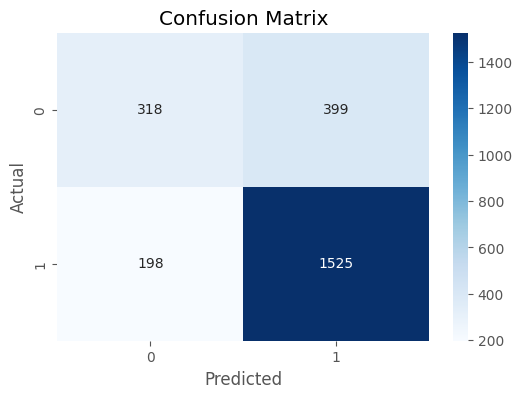

```
Logistic Regression - Dogs Binary:
Classification Report:
              precision    recall  f1-score   support

           0       0.61      0.17      0.26       717
           1       0.73      0.96      0.83      1723

    accuracy                           0.72      2440
   macro avg       0.67      0.56      0.55      2440
weighted avg       0.70      0.72      0.66      2440

Confusion Matrix:
[[ 120  597]
 [  77 1646]]
```

[8 more figures not shown]

```python
df = pd.read_csv('PetFinder_dataset.csv')


# Preprocess the data for binary classification (Adopted)
def preprocess_binary_classification(df):
    # Drop irrelevant columns
    df_cleaned = df.drop(columns=['PetID', 'RescuerID', 'Name', 'Description'])

    # Convert 'AdoptionSpeed' to binary 'Adopted' column: 1 if AdoptionSpeed != 4, 0 if AdoptionSpeed == 4
    df_cleaned['Adopted'] = df_cleaned['AdoptionSpeed'].apply(lambda x: 1 if x != 4 else 0)

    # Drop the original 'AdoptionSpeed' as it's no longer needed for binary classification
    df_cleaned = df_cleaned.drop(columns=['AdoptionSpeed'])

    # Convert categorical columns to category type
    categorical_columns = ['Type', 'Gender', 'Color1', 'Color2', 'Color3', 'MaturitySize',
                           'FurLength', 'Vaccinated', 'Dewormed', 'Sterilized', 'Health', 'State']

    for col in categorical_columns:
        df_cleaned[col] = df_cleaned[col].astype('category')

    # Apply Label Encoding to ordinal categorical columns
    label_columns = ['MaturitySize', 'FurLength', 'Vaccinated', 'Dewormed', 'Sterilized', 'Health']
    label_encoder = LabelEncoder()
    for col in label_columns:
        df_cleaned[col] = label_encoder.fit_transform(df_cleaned[col])

    # One-Hot Encoding for nominal categorical columns (e.g., 'Type', 'Gender', 'Color1', etc.)
    df_cleaned = pd.get_dummies(df_cleaned, columns=['Gender', 'Color1', 'Color2', 'Color3', 'State', 'Type'], drop_first=True)

    return df_cleaned

# Function to preprocess for multiclass classification (AdoptionSpeed)
def preprocess_multiclass_classification(df):
    # Drop irrelevant columns
    df_cleaned = df.drop(columns=['PetID', 'RescuerID', 'Name', 'Description'])

    # Convert 'AdoptionSpeed' to a multiclass target
    df_cleaned['AdoptionSpeed'] = df_cleaned['AdoptionSpeed'].astype(int)

    # Convert categorical columns to category type
    categorical_columns = ['Type', 'Gender', 'Color1', 'Color2', 'Color3', 'MaturitySize',
                           'FurLength', 'Vaccinated', 'Dewormed', 'Sterilized', 'Health', 'State']

    for col in categorical_columns:
        df_cleaned[col] = df_cleaned[col].astype('category')

    # Apply Label Encoding to ordinal categorical columns
    label_columns = ['MaturitySize', 'FurLength', 'Vaccinated', 'Dewormed', 'Sterilized', 'Health']
    label_encoder = LabelEncoder()
    for col in label_columns:
        df_cleaned[col] = label_encoder.fit_transform(df_cleaned[col])

    # One-Hot Encoding for nominal categorical columns (e.g., 'Type', 'Gender', 'Color1', etc.)
    df_cleaned = pd.get_dummies(df_cleaned, columns=['Gender', 'Color1', 'Color2', 'Color3', 'State', 'Type'], drop_first=True)

    return df_cleaned

# Separate data into two datasets: one for cats and one for dogs
df_cats = df[df['Type'] == 2]
df_dogs = df[df['Type'] == 1]

# Preprocess the data for binary and multiclass classification
data_cats_binary = preprocess_binary_classification(df_cats)
data_dogs_binary = preprocess_binary_classification(df_dogs)

data_cats_multiclass = preprocess_multiclass_classification(df_cats)
data_dogs_multiclass = preprocess_multiclass_classification(df_dogs)

# Prepare features (X) and target (y) for binary classification
X_cats_binary = data_cats_binary.drop(columns=['Adopted'])
y_cats_binary = data_cats_binary['Adopted']

X_dogs_binary = data_dogs_binary.drop(columns=['Adopted'])
y_dogs_binary = data_dogs_binary['Adopted']

# Prepare features (X) and target (y) for multiclass classification
X_cats_multiclass = data_cats_multiclass.drop(columns=['AdoptionSpeed'])
y_cats_multiclass = data_cats_multiclass['AdoptionSpeed']

X_dogs_multiclass = data_dogs_multiclass.drop(columns=['AdoptionSpeed'])
y_dogs_multiclass = data_dogs_multiclass['AdoptionSpeed']

# Train-Test Split (for both binary and multiclass)
X_cats_train, X_cats_test, y_cats_train, y_cats_test = train_test_split(X_cats_binary, y_cats_binary, test_size=0.3, random_state=42)
X_dogs_train, X_dogs_test, y_dogs_train, y_dogs_test = train_test_split(X_dogs_binary, y_dogs_binary, test_size=0.3, random_state=42)

X_cats_multiclass_train, X_cats_multiclass_test, y_cats_multiclass_train, y_cats_multiclass_test = train_test_split(X_cats_multiclass, y_cats_multiclass, test_size=0.3, random_state=42)
X_dogs_multiclass_train, X_dogs_multiclass_test, y_dogs_multiclass_train, y_dogs_multiclass_test = train_test_split(X_dogs_multiclass, y_dogs_multiclass, test_size=0.3, random_state=42)

# Initialize classifiers
classifiers = {
    'Decision Tree': DecisionTreeClassifier(),
    'Random Forest': RandomForestClassifier(),
    'Logistic Regression': LogisticRegression(max_iter=1000),
    'Naive Bayes': GaussianNB(),
    'SVM': SVC()
}

# Helper function to evaluate models
def evaluate_model(clf, X_train, X_test, y_train, y_test):
    clf.fit(X_train, y_train)
    y_pred = clf.predict(X_test)

    print(f"Classification Report:\n{classification_report(y_test, y_pred)}")
    cm = confusion_matrix(y_test, y_pred)
    print(f"Confusion Matrix:\n{cm}")
    plt.figure(figsize=(6, 4))
    sns.heatmap(cm, annot=True, fmt='d', cmap='Blues', xticklabels=np.unique(y_test), yticklabels=np.unique(y_test))
    plt.title('Confusion Matrix')
    plt.xlabel('Predicted')
    plt.ylabel('Actual')
    plt.show()

# Evaluate models for cats (binary and multiclass)
print("Evaluating Cats - Binary Classification (Adopted)")
for name, clf in classifiers.items():
    print(f"\n{name} - Cats Binary:")
    evaluate_model(clf, X_cats_train, X_cats_test, y_cats_train, y_cats_test)

print("Evaluating Cats - Multiclass Classification (AdoptionSpeed)")
for name, clf in classifiers.items():
    print(f"\n{name} - Cats Multiclass:")
    evaluate_model(clf, X_cats_multiclass_train, X_cats_multiclass_test, y_cats_multiclass_train, y_cats_multiclass_test)

# Evaluate models for dogs (binary and multiclass)
print("Evaluating Dogs - Binary Classification (Adopted)")
for name, clf in classifiers.items():
    print(f"\n{name} - Dogs Binary:")
    evaluate_model(clf, X_dogs_train, X_dogs_test, y_dogs_train, y_dogs_test)

print("Evaluating Dogs - Multiclass Classification (AdoptionSpeed)")
for name, clf in classifiers.items():
    print(f"\n{name} - Dogs Multiclass:")
    evaluate_model(clf, X_dogs_multiclass_train, X_dogs_multiclass_test, y_dogs_multiclass_train, y_dogs_multiclass_test)
```

## Task 2 (Unsupervised Learning) - Charactering Pets and their Adoption Speed

In this task you should **use unsupervised learning to characterize pets and their adoption speed**. You have 2 clustering:

1. **Use Clustering algorithms to find similar groups of adopted pets.** When animals are adopted, is it possible to find groups of pets with the same/similar adoption speed? Evaluate clustering results using **internal and external metrics**.
2. **Be creative and define and explore your own unsupervised learning task!** What else would it be interesting to find out?

## 2.1. Preprocessing Data for Clustering

This section of the script applies **unsupervised learning** techniques to cluster the pets based on their features and explore patterns in the adoption process using the **PetFinder dataset**. The main focus is to uncover relationships between pet characteristics and their adoption speed without using explicit labels.

The overall goal is to see if the unsupervised KMeans algorithm can reveal meaningful patterns in the adoption process, potentially linking certain pet characteristics to their likelihood of adoption speed.

```
Silhouette Score for KMeans: 0.0974
Adjusted Rand Index for KMeans: -0.0023
```

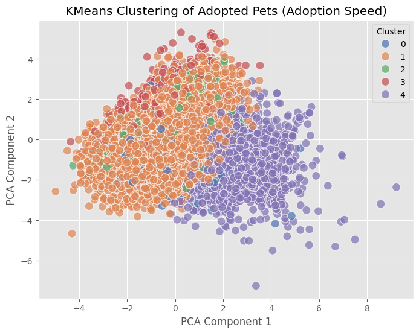

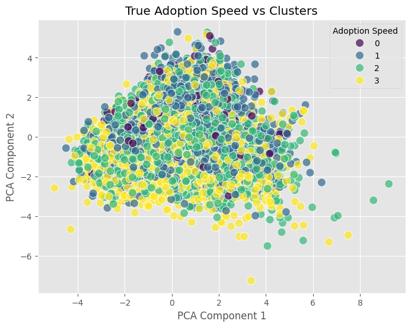

```python
df = pd.read_csv('PetFinder_dataset.csv')


# Define preprocessing function for clustering
def preprocess_for_clustering(df):
    # Drop irrelevant columns for clustering
    df_cleaned = df.drop(columns=['PetID', 'RescuerID', 'Name', 'Description'])  # Remove only columns relevant to clustering

    # Convert categorical columns to category type
    categorical_columns = ['Type', 'Gender', 'Color1', 'Color2', 'Color3', 'MaturitySize',
                           'FurLength', 'Vaccinated', 'Dewormed', 'Sterilized', 'Health', 'State']

    for col in categorical_columns:
        df_cleaned[col] = df_cleaned[col].astype('category')

    # Apply Label Encoding to ordinal categorical columns
    label_columns = ['MaturitySize', 'FurLength', 'Vaccinated', 'Dewormed', 'Sterilized', 'Health']
    label_encoder = LabelEncoder()
    for col in label_columns:
        df_cleaned[col] = label_encoder.fit_transform(df_cleaned[col])

    # One-Hot Encoding for nominal categorical columns
    df_cleaned = pd.get_dummies(df_cleaned, columns=['Gender', 'Color1', 'Color2', 'Color3', 'State', 'Type'], drop_first=True)

    # Standardize the features (important for clustering)
    scaler = StandardScaler()
    df_scaled = scaler.fit_transform(df_cleaned)

    return df_scaled

# Preprocess the data
X_scaled = preprocess_for_clustering(df)

# Task 2.1: Clustering with KMeans
# We will try to find groups based on the `AdoptionSpeed` column to see if clustering algorithms can uncover patterns related to adoption speed.

# 1. First, we separate pets based on their adoption speed (5 classes: {0, 1, 2, 3, 4})
df_adopted = df[df['AdoptionSpeed'] != 4]  # We will focus on adopted pets (AdoptionSpeed != 4)
X_adopted_scaled = preprocess_for_clustering(df_adopted)

# 2. Apply KMeans Clustering
kmeans = KMeans(n_clusters=5, random_state=42)
df_adopted['Cluster'] = kmeans.fit_predict(X_adopted_scaled)

# 3. Evaluate the Clustering Performance
# Internal Metric: Silhouette Score
sil_score = silhouette_score(X_adopted_scaled, df_adopted['Cluster'])
print(f"Silhouette Score for KMeans: {sil_score:.4f}")

# External Metric: Adjusted Rand Index (ARI)
# We compare the clustering results with the true labels (AdoptionSpeed)
ari_score = adjusted_rand_score(df_adopted['AdoptionSpeed'], df_adopted['Cluster'])
print(f"Adjusted Rand Index for KMeans: {ari_score:.4f}")

# 4. Visualize the Clustering Results
# We will reduce the dimensionality of the data using PCA (Principal Component Analysis) for visualization

pca = PCA(n_components=2)
X_pca = pca.fit_transform(X_adopted_scaled)

# Plot the clusters in 2D space
plt.figure(figsize=(8, 6))
sns.scatterplot(x=X_pca[:, 0], y=X_pca[:, 1], hue=df_adopted['Cluster'], palette="deep", s=100, alpha=0.7)
plt.title("KMeans Clustering of Adopted Pets (Adoption Speed)")
plt.xlabel("PCA Component 1")
plt.ylabel("PCA Component 2")
plt.legend(title="Cluster")
plt.show()

# Compare the clusters to the true adoption speeds
plt.figure(figsize=(8, 6))
sns.scatterplot(x=X_pca[:, 0], y=X_pca[:, 1], hue=df_adopted['AdoptionSpeed'], palette="viridis", s=100, alpha=0.7)
plt.title("True Adoption Speed vs Clusters")
plt.xlabel("PCA Component 1")
plt.ylabel("PCA Component 2")
plt.legend(title="Adoption Speed")
plt.show()
```